# Simulated data

Here’s a function to simulate data:

```r
siminds <- function (dhet,phet,coverage,nloci=1e6,perr=0.01) {
    # dhet is density of segregegating sites
    # phet and coverage are vectors
    stopifnot(all(phet<=dhet))
    nsamples <- length(coverage)
    # same segregating sites between torts
    het.sites <- rbinom( nloci, size=1, prob=dhet )
    hets <- do.call( cbind, lapply( 1:nsamples, function (k) {
                rbinom( nloci, size=1, prob=ifelse(het.sites,phet[k]/dhet,0) )
            } ) )
    coverages <- do.call( cbind, lapply( 1:nsamples, function (k) {
                rpois( nloci, coverage[k] )
            } ) )
    counts <- sapply( 1:nsamples, function (k) {
            rbinom( nloci, size=coverages[,k], prob=ifelse(hets[,k],1/2,perr) )
        } )
    return(list(coverages=coverages,counts=counts))
}
```

And here’s a function to compute heterozygosities:

```r
pwp <- function (counts,coverages) {
    pwp <- numeric( ncol(coverages)^2 )
    dim(pwp) <- c( ncol(coverages), ncol(coverages) )
    for (i in 1:ncol(coverages)) {
        for (j in 1:ncol(coverages)) {
            weights <- (coverages[,i]) * (coverages[,j] - if (i==j){1}else{0} )
            if (i!=j) {
                w.probs <- counts[,i] * (coverages[,j]-counts[,j]) + (coverages[,i]-counts[,i]) * counts[,j]
                pwp[i,j] <- sum( w.probs, na.rm=TRUE ) / sum(weights)
            } else {
                usethese <- ( coverages[,i] > 1 )
                w.probs <- 2 * counts[,i] * (coverages[,i]-counts[,i])
                pwp[i,i] <- sum( w.probs[usethese] ) / sum(weights[usethese])
            }
        }
    }
    return(pwp)
}
```

And, a function to return the right answer:

```r
truth <- function (dhet, phet) {
    # (not segr) * (diff in error) + (segr) * (prob diff if het in at least one) * (prob het if segr)
    phet.mat <- (1-outer(1-phet/dhet,1-phet/dhet,"*"))
    diag(phet.mat) <- phet/dhet
    return( (1-dhet) * 2*perr*(1-perr) + dhet * (1/2) * phet.mat )
}
```

Let’s try it out, with a range of coverages:

```r
perr <- 0.01
dhet <- 0.02
coverage <- rep(c(4,2,1,0.5),each=2)
phet <- rep(0.009,length(coverage))
simdata <- siminds(dhet=dhet, phet=phet, coverage=coverage, perr=perr)
true.pwp <- truth(dhet,phet)
est.pwp <- pwp( simdata$counts, simdata$coverages )
```

The right answer should be 0.023904, 0.026379, 0.026379, 0.026379, 0.026379, 0.026379, 0.026379, 0.026379, 0.026379, 0.023904, 0.026379, 0.026379, 0.026379, 0.026379, 0.026379, 0.026379, 0.026379, 0.026379, 0.023904, 0.026379, 0.026379, 0.026379, 0.026379, 0.026379, 0.026379, 0.026379, 0.026379, 0.023904, 0.026379, 0.026379, 0.026379, 0.026379, 0.026379, 0.026379, 0.026379, 0.026379, 0.023904, 0.026379, 0.026379, 0.026379, 0.026379, 0.026379, 0.026379, 0.026379, 0.026379, 0.023904, 0.026379, 0.026379, 0.026379, 0.026379, 0.026379, 0.026379, 0.026379, 0.026379, 0.023904, 0.026379, 0.026379, 0.026379, 0.026379, 0.026379, 0.026379, 0.026379, 0.026379, 0.023904; we get

```r
est.pwp
```

```
##            [,1]       [,2]       [,3]       [,4]       [,5]       [,6]
## [1,] 0.02408764 0.02663004 0.02655120 0.02646668 0.02648707 0.02659077
## [2,] 0.02663004 0.02437742 0.02666516 0.02658644 0.02659990 0.02647474
## [3,] 0.02655120 0.02666516 0.02411609 0.02649829 0.02655273 0.02648371
## [4,] 0.02646668 0.02658644 0.02649829 0.02403365 0.02656398 0.02651176
## [5,] 0.02648707 0.02659990 0.02655273 0.02656398 0.02422546 0.02642996
## [6,] 0.02659077 0.02647474 0.02648371 0.02651176 0.02642996 0.02406213
## [7,] 0.02657227 0.02660480 0.02664067 0.02600431 0.02680241 0.02663899
## [8,] 0.02614471 0.02619771 0.02657115 0.02628730 0.02622435 0.02636510
##            [,7]       [,8]
## [1,] 0.02657227 0.02614471
## [2,] 0.02660480 0.02619771
## [3,] 0.02664067 0.02657115
## [4,] 0.02600431 0.02628730
## [5,] 0.02680241 0.02622435
## [6,] 0.02663899 0.02636510
## [7,] 0.02430004 0.02651771
## [8,] 0.02651771 0.02394303
```

with relative error

```r
est.pwp/true.pwp - 1.0
```

```
##              [,1]         [,2]        [,3]         [,4]         [,5]
## [1,]  0.007682265  0.009516831 0.006527827  0.003324035  0.004096996
## [2,]  0.009516831  0.019805214 0.010848177  0.007863903  0.008374243
## [3,]  0.006527827  0.010848177 0.008872639  0.004522048  0.006585899
## [4,]  0.003324035  0.007863903 0.004522048  0.005423876  0.007012502
## [5,]  0.004096996  0.008374243 0.006585899  0.007012502  0.013448116
## [6,]  0.008028060  0.003629356 0.003969304  0.005032889  0.001931830
## [7,]  0.007326649  0.008559936 0.009919777 -0.014204228  0.016050968
## [8,] -0.008881633 -0.006872556 0.007284042 -0.003476399 -0.005862709
##              [,6]         [,7]         [,8]
## [1,]  0.008028060  0.007326649 -0.008881633
## [2,]  0.003629356  0.008559936 -0.006872556
## [3,]  0.003969304  0.009919777  0.007284042
## [4,]  0.005032889 -0.014204228 -0.003476399
## [5,]  0.001931830  0.016050968 -0.005862709
## [6,]  0.006615098  0.009855965 -0.000527113
## [7,]  0.009855965  0.016567943  0.005258168
## [8,] -0.000527113  0.005258168  0.001632637
```

## Bias?

Now let’s do this a bunch of times to get the distribution of the estimator. I’ll do it with fewer sites, so it doesn’t take forever.

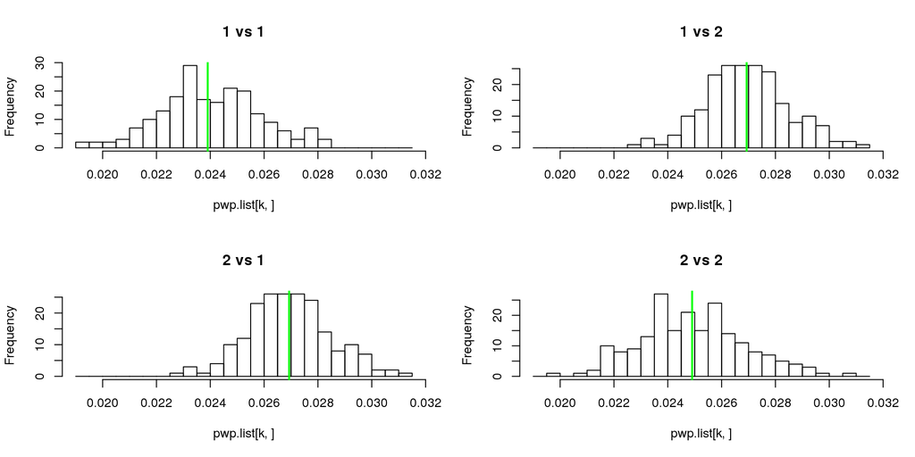

```r
coverage <- c(2,2)
phet <- c(.009,.011)
true.pwp <- truth(dhet,phet)
simdata.list <- lapply( 1:200, function (k) {
        siminds( dhet=dhet, phet=phet, coverage=coverage, perr=perr, nloci=1e4 )
    } )
sim.names <- outer(1:2,1:2,paste,sep=" vs ")
pwp.list <- sapply( simdata.list, function (ll) {
        pwp( ll$counts, ll$coverages )
    } )
hpwp <- hist( unlist(pwp.list), breaks=30, plot=FALSE )
layout(matrix(1:4,nrow=2))
for (k in 1:4) {
    hist( pwp.list[k,], breaks=hpwp$breaks, main=sim.names[k] )
    abline(v=true.pwp[k],col='green',lwd=2)
}
```

That looks pretty good.

## “With replacement” computation

Let’s try the alternative estimator, which estimates the probability that two reads differ, sampling *with* replacement:

```r
pwp.rep <- function (counts,coverages) {
    pwp <- numeric( ncol(coverages)^2 )
    dim(pwp) <- c( ncol(coverages), ncol(coverages) )
    for (i in 1:ncol(coverages)) {
        for (j in 1:ncol(coverages)) {
            weights <- coverages[,i] * coverages[,j]
            if (i!=j) {
                w.probs <- counts[,i] * (coverages[,j]-counts[,j]) + (coverages[,i]-counts[,i]) * counts[,j]
                pwp[i,j] <- sum( w.probs, na.rm=TRUE ) / sum(weights)
            } else {
                w.probs <- 2 * counts[,i] * (coverages[,i]-counts[,i])
                pwp[i,i] <- sum( w.probs ) / sum(weights)
            }
        }
    }
    return(pwp)
}
```

and on the same data as above,

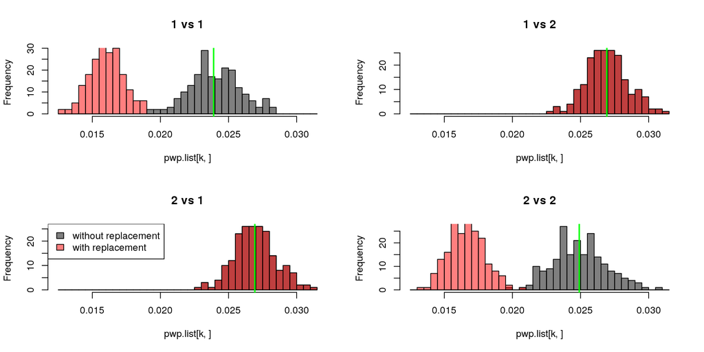

```r
pwp.rep.list <- sapply( simdata.list, function (ll) {
        pwp.rep( ll$counts, ll$coverages )
    } )
hpwp <- hist( unlist(c(pwp.list,pwp.rep.list)), breaks=30, plot=FALSE )
layout(matrix(1:4,nrow=2))
for (k in 1:4) {
    hist( pwp.list[k,], breaks=hpwp$breaks, main=sim.names[k], col=adjustcolor("black",.5) )
    hist( pwp.rep.list[k,], breaks=hpwp$breaks, col=adjustcolor("red",.5), add=TRUE )
    abline(v=true.pwp[k],col='green',lwd=2)
    if (k==2) { legend("topleft",fill=adjustcolor(c("black","red"),.5),legend=c("without replacement","with replacement") ) }
}
```

## “With replacement” weighting only

Now let’s experiment with changing the *weightings*, which shouldn’t affect the correctness of the estimator in this case, since we haven’t yet put in any correlations between coverage and error (say).

```r
pwp.wei <- function (counts,coverages) {
    pwp <- numeric( ncol(coverages)^2 )
    dim(pwp) <- c( ncol(coverages), ncol(coverages) )
    for (i in 1:ncol(coverages)) {
        for (j in 1:ncol(coverages)) {
            weights <- (coverages[,i]) * coverages[,j]
            if (i!=j) {
                probs <- counts[,i]/coverages[,i] * (1-counts[,j]/coverages[,j]) + (1-counts[,i]/coverages[,i]) * counts[,j]/coverages[,j]
                pwp[i,j] <- sum( weights*probs, na.rm=TRUE ) / sum(weights)
            } else {
                usethese <- ( coverages[,i] > 1 )
                probs <- 2 * counts[,i] * (coverages[,i]-counts[,i]) / ( coverages[,i] * (coverages[,i]-1) )
                pwp[i,i] <- sum( (weights*probs)[usethese] ) / sum(weights[usethese])
            }
        }
    }
    return(pwp)
}
```

and on the same data as above,

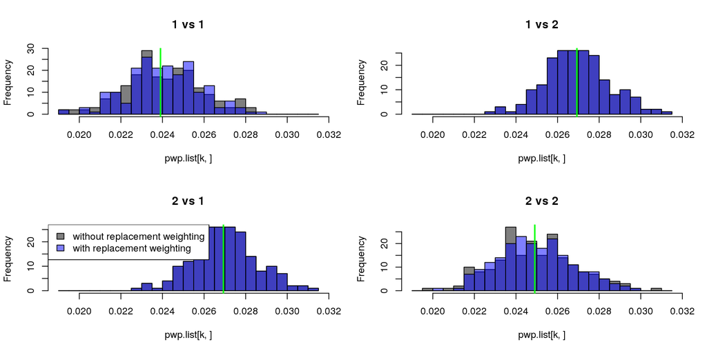

```r
pwp.wei.list <- sapply( simdata.list, function (ll) {
        pwp.wei( ll$counts, ll$coverages )
    } )
hpwp <- hist( unlist(c(pwp.list,pwp.wei.list)), breaks=30, plot=FALSE )
layout(matrix(1:4,nrow=2))
for (k in 1:4) {
    hist( pwp.list[k,], breaks=hpwp$breaks, main=sim.names[k], col=adjustcolor("black",.5) )
    hist( pwp.wei.list[k,], breaks=hpwp$breaks, col=adjustcolor("blue",.5), add=TRUE )
    abline(v=true.pwp[k],col='green',lwd=2)
    if (k==2) { legend("topleft",fill=adjustcolor(c("black","blue"),.5),legend=c("without replacement weighting","with replacement weighting") ) }
}
```

# Efficiency

Here’s the original function

```r
pwp.1 <- function (counts,coverages) {
    pwp <- numeric( ncol(coverages)^2 )
    dim(pwp) <- c( ncol(coverages), ncol(coverages) )
    for (i in 1:ncol(coverages)) {
        for (j in 1:ncol(coverages)) {
            weights <- (coverages[,i]) * (coverages[,j] - if (i==j){1}else{0} )
            if (i!=j) {
                probs <- counts[,i]/coverages[,i] * (1-counts[,j]/coverages[,j]) + (1-counts[,i]/coverages[,i]) * counts[,j]/coverages[,j]
                pwp[i,j] <- sum( weights*probs, na.rm=TRUE ) / sum(weights)
            } else {
                usethese <- ( coverages[,i] > 1 )
                probs <- 2 * counts[,i] * (coverages[,i]-counts[,i]) / ( coverages[,i] * (coverages[,i]-1) )
                pwp[i,i] <- sum( (weights*probs)[usethese] ) / sum(weights[usethese])
            }
        }
    }
    return(pwp)
}
```

And here’s the more efficient version:

```r
pwp.2 <- function (counts,coverages) {
    pwp <- numeric( ncol(coverages)^2 )
    dim(pwp) <- c( ncol(coverages), ncol(coverages) )
    for (i in 1:ncol(coverages)) {
        for (j in 1:ncol(coverages)) {
            weights <- (coverages[,i]) * (coverages[,j] - if (i==j){1}else{0} )
            if (i!=j) {
                w.probs <- counts[,i] * (coverages[,j]-counts[,j]) + (coverages[,i]-counts[,i]) * counts[,j]
                pwp[i,j] <- sum( w.probs, na.rm=TRUE ) / sum(weights)
            } else {
                usethese <- ( coverages[,i] > 1 )
                w.probs <- 2 * counts[,i] * (coverages[,i]-counts[,i])
                pwp[i,i] <- sum( w.probs[usethese] ) / sum(weights[usethese])
            }
        }
    }
    return(pwp)
}
```

Check these do the same thing:

```r
est.pwp.1 <- pwp.1( simdata$counts, simdata$coverages )
est.pwp.2 <- pwp.2( simdata$counts, simdata$coverages )
all.equal(est.pwp.1,est.pwp.2)
```

```
## [1] TRUE
```

and the difference in speed

```r
require(microbenchmark)
ns <- 1e4
microbenchmark( pwp.1( simdata$counts[1:ns,], simdata$coverages[1:ns,] ), times=20 )
```

```
## Unit: milliseconds
##                                                      expr      min
##  pwp.1(simdata$counts[1:ns, ], simdata$coverages[1:ns, ]) 52.01591
##        lq    mean   median       uq      max neval
##  52.15575 53.5632 53.49166 53.75391 57.79676    20
```

```r
microbenchmark( pwp.2( simdata$counts[1:ns,], simdata$coverages[1:ns,] ), times=20 )
```

```
## Unit: milliseconds
##                                                      expr     min       lq
##  pwp.2(simdata$counts[1:ns, ], simdata$coverages[1:ns, ]) 41.0159 41.17815
##     mean   median       uq      max neval
##  41.8824 41.40255 42.68792 44.25709    20
```

Hm, a 20% speedup. Not as much as I imagined, but worth it.

Note that we’d save ourselves a lot of subtractions if we precomputed `coverages-counts`.